# Importing the data into R and Signac+Seurat, initial QC and clustering

### Summary visualization of multiple quality metrics stats

We can also plot various features (the ones we manually defined above) at the same time in a Violin plot:

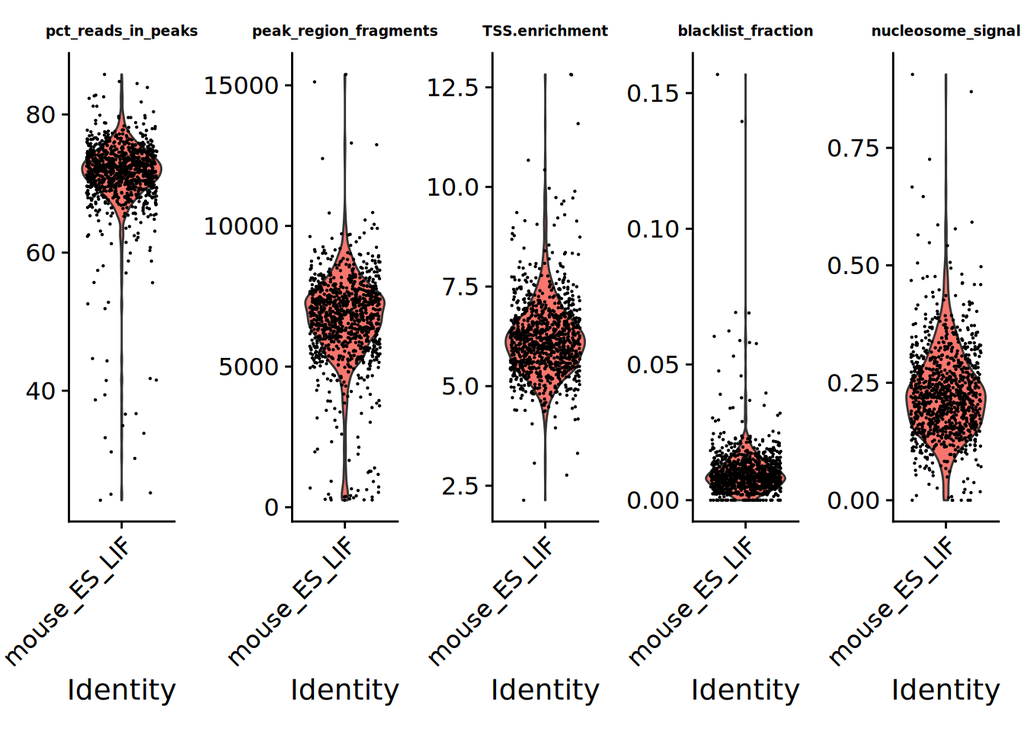

```r
VlnPlot(
  object = seu,
  features = c('pct_reads_in_peaks', 'peak_region_fragments', 'TSS.enrichment',
               'blacklist_fraction', 'nucleosome_signal'),
  pt.size = 0.1,
  ncol = 5
) & theme(plot.title = element_text(size = 7))
```

## Final filtering

After initial QC, we are now ready to filter our object and include only cells that pass our QC filters. That is, we remove cells that are outliers for the QC metrics that we defined above or that have been identified as doublets. Note that setting thresholds for filters is in a way very subjective and you may want to test different thresholds in order to judge their suitability and whether the applied stringency is sufficient for downstream analyses.

```r
seu.s <- subset(
  x = seu,
  subset = peak_region_fragments > 1000 &
    peak_region_fragments < 15000 &
    pct_reads_in_peaks > 40 &
    blacklist_fraction < 0.05 &
    nucleosome_signal < 1.5 &
    TSS.enrichment > 2 &
    ATAC_doublets == "singlet"
)

# For testing purposes, we are here subsetting the seurat object to 20k peaks and 5k cells.

######################################################
# Do NOT execute this line when you run the vignette #
######################################################
seu.s = seu.s[1:20000, 1:5000]

seu.s
```

```
An object of class Seurat
20000 features across 941 samples within 1 assay
Active assay: ATAC (20000 features, 0 variable features)
 2 layers present: counts, data
```

As you can see, this retained most of the cells but not all!

## Save unfiltered object to disk

It is time to save our original Seurat object to disk! We do so in a special format, called `rds`, which we can use later to quickly load our Seurat object back into R using the function `readRDS()`. In fact, in all other vignettes that we will use in the course, this will be our first step: Loading the preprocessed Seurat object into R using the `readRDS()` function!

```r
# If we are sure that we do not use the unfiltered seu object anymore,
# we can delete it here, or save it to disk
saveRDS(seu, file = paste0(outFolder,"obj.rds"))

# Let us not delete it here to allow changing the filtering above
# if you need to save memory, delete the (unfiltered) Seurat oject
rm(seu)
```

## Normalization and dimensionality reduction

The combined steps of TF-IDF followed by SVD are known as latent semantic indexing (LSI), and were first introduced for the analysis of scATAC-seq data by [Cusanovich et al. 2015](https://science.sciencemag.org/content/367/6473/45.full).

You may have heard about `scTransform` for scRNA-seq data, wondering whether we can also apply this to scATAC-Seq data. The short answer: no. The reason is as follows: `scTransform`expects the data to follow a negative binomial or poisson distribution, which is not the case for scATAC data. It is also trying to normalize the data in a way that accounts for the strong mean-variance relationship in scRNA-seq, which is not something that we observe in scATAC due to the much lower dynamic range. From a practical perspective also, we want to preserve the sparsity of the data when normalizing scATAC-seq due to the large number of features we have. If we performed a normalization that lost the sparsity, we would have a very large dense matrix that will require a huge amount of memory to hold. As you can see, each data type requires its own specific normalization that incorporates the data-type specifics.

**In the following, we give more background on dimensionality reduction with scATAC-seq data, which we took from the [archR website](https://www.archrproject.com/bookdown/dimensionality-reduction-with-archr.html)**. In general, dimensionality reduction with scATAC-seq is challenging due to the sparsity of the data. In scATAC-seq, a particular site can either be accessible on one allele, both alleles, or no alleles. Even in higher-quality scATAC-seq data, the majority of accessible regions are not transposed and this leads to many loci having 0 accessibility alleles. Moreover, when we see (for example) three Tn5 insertions within a single peak region in a single cell, the sparsity of the data prevents us from confidently determining that this site in this cell is actually three times more accessible than another cell that only has one insertion in the same site. For this reason a lot of analytical strategies work on a binarized scATAC-seq data matrix. This binarized matrix still ends up being mostly 0s because transposition is rare. However, it is important to note that a 0 in scATAC-seq could mean “non-accessible” or “not sampled” and these two inferences are very different from a biological standpoint. Because of this, the 1s have information and the 0s do not. This low information content is what makes our scATAC-seq data sparse.

If you were to perform a standard dimensionality reduction, like *Principal Component Analysis* (PCA), on this sparse insertion counts matrix and plot the top two principal components (PCs), you would not obtain the desired result because the sparsity causes high inter-cell similarity at all of the 0 positions. To get around this issue, we use a layered dimensionality reduction approach. First, we use *Latent Semantic Indexing* (LSI), an approach from natural language processing that was originally designed to assess document similarity based on word counts. This solution was created for natural language processing because the data is sparse and noisy (many different words and many low frequency words). LSI was first introduced for scATAC-seq by *Cusanovich et al*. (Science 2015). In the case of scATAC-seq, different samples are the documents and different regions/peaks are the words. First, we calculate the term frequency by depth normalization per single cell. These values are then normalized by the inverse document frequency which weights features by how often they occur to identify features that are more “specific” rather than commonly accessible. The resultant *term frequency-inverse document frequency* (TF-IDF) matrix reflects how important a word (aka region/peak) is to a document (aka sample). Then, through a technique called *singular value decomposition* (SVD), the most valuable information across samples is identified and represented in a lower dimensional space. LSI allows you to reduce the dimensionality of the sparse insertion counts matrix from many thousands to tens or hundreds. Then, a more conventional dimensionality reduction technique, such as *Uniform Manifold Approximation and Projection* (UMAP) or *t-distributed stochastic neighbor embedding* (t-SNE) (see below) can be used to visualize the data. Let’s create a two-dimensional *embedding* of the data!

```r
seu.s <- seu.s %>%
        RunTFIDF(method = 1) %>%
        FindTopFeatures(min.cutoff = "q25") %>%
        RunSVD(reduction.key = 'LSI_', reduction.name = 'lsi')
```

### Examining the LSI components and removing components

The first LSI component often captures sequencing depth (technical variation) rather than biological variation. If this is the case, the component should be removed from downstream analysis. We can assess the correlation between each LSI component and sequencing depth using the `DepthCor()` function:

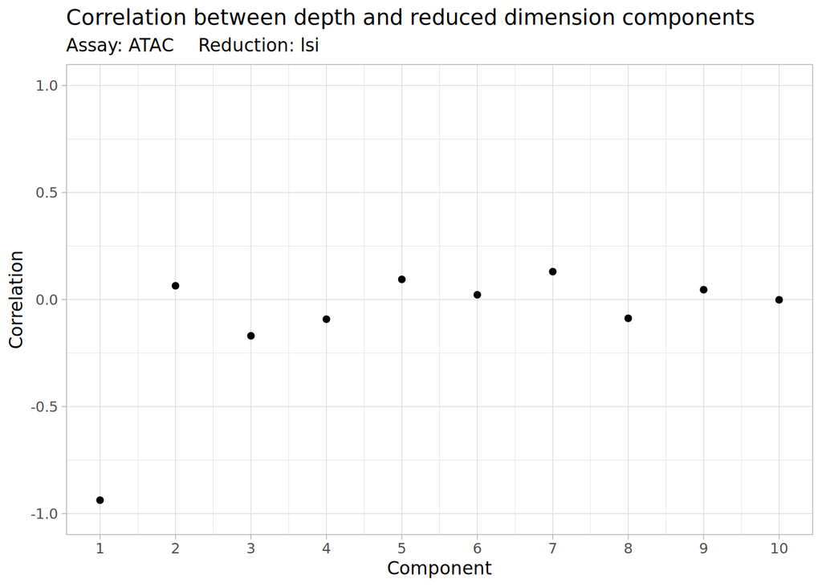

```r
p1 = DepthCor(seu.s, reduction = "lsi")
p1
```

Here we see there is a very strong (negative) correlation between the first LSI component and the total number of counts for the cell, so we will perform downstream steps without this component.

## Non-linear dimension reduction for visualization and clustering

Now that the cells are embedded in a low-dimensional space, we can use methods commonly applied for the analysis of scRNA-seq data to perform graph-based clustering and non-linear dimension reduction for visualization. The functions `RunUMAP()`, `FindNeighbors()`, and `FindClusters()` all come from the Seurat package.

### Visualize embeddings: UMAP

Th following description is taken and slightly modified from [here](https://www.archrproject.com/bookdown/single-cell-embeddings.html). In general, embeddings such as *Uniform Manifold Approximation and Projection* (UMAP) or *t-distributed stochastic neighbor embedding* (t-SNE), are used to visualize single cells in reduced dimension space. They each have distinct advantages and disadvantages. We call them *embeddings* because they are strictly used to visualize the clusters and are not used to identify clusters which is done in an LSI sub-space as mentioned before. The primary difference between UMAP and t-SNE is the interpretation of the distance between cells or clusters. t-SNE is designed to preserve the local structure in the data while UMAP is designed to preserve both the local and most of the global structure in the data. In theory, this means that the distance between two clusters is not informative in t-SNE but is informative in UMAP. For example, t-SNE does not allow you to say that Cluster A is more similar to Cluster B than it is to Cluster C based on the observation that Cluster A is located closer to Cluster B than Cluster C on the t-SNE. UMAP, on the other hand, is designed to permit this type of comparison, though it is worth noting that UMAP is a new enough method that this is still being flushed out in the literature.

It is important to note that neither t-SNE nor UMAP are naturally deterministic (same input always gives exactly the same output). However, t-SNE shows much more randomness across multiple replicates of the same input than does UMAP. Moreover, UMAP as implemented in the `uwot` package is effectively deterministic when using the same random seed. The choice of whether to use UMAP or t-SNE is nuanced but from our experience, UMAP works very well for a diverse set of applications and this is our standard choice for scATAC-seq data. UMAP also performs faster than t-SNE. Perhaps most importantly, with UMAP you can create an embedding and project new samples into that embedding and this is not possible with t-SNE because the fitting and prediction of data happens simultaneously.

Regardless of which method you choose, the input parameters can have drastic effects on the resulting embedding. Because of this, it is important to understand the various input parameters and to tweak these to best meet the needs of your own data.

Here, due to the aforementioned advantages of UMAP, we will focus on UMAPs only and ignore t-SNE. Feel free to also produce t-SNE plots if you are interested!

```r
# First, we explicitly define some parameters for creating the UMAP and
# subsequent functions related to clustering

# Exclude the first LSI component due to the strong correlation, see the plot above
dims_sel = 2:20
nn = 30
res = 0.5
clusters_alg = 1

# We are now ready to run it!
seu.s <- seu.s %>%
            RunUMAP(dims = dims_sel,
                    n.neighbors = nn, verbose = FALSE,
                     # a = 0.9, b = 0.6,
                    metric = "cosine",
                    reduction = "lsi") %>%
            FindNeighbors(dims = dims_sel,
                          graph.name = "ATAC_snn",reduction = "lsi") %>%
            FindClusters(resolution = res, algorithm = clusters_alg,
                         graph.name = "ATAC_snn")
```

```
Modularity Optimizer version 1.3.0 by Ludo Waltman and Nees Jan van Eck

Number of nodes: 941
Number of edges: 8355

Running Louvain algorithm...
Maximum modularity in 10 random starts: 0.5189
Number of communities: 2
Elapsed time: 0 seconds
```

### Visualize clusters in embedded space

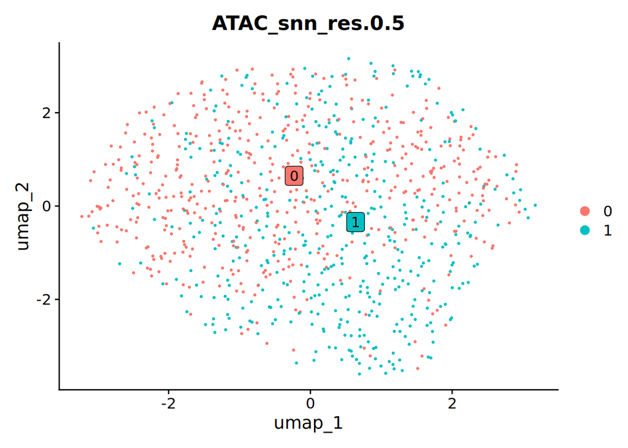

```r
res = 0.5

DimPlot(object = seu.s, pt.size = 0.5,
            group.by = paste0("ATAC_snn_res.",res),
            label = TRUE, repel = TRUE, label.box = TRUE)
```

### Cluster stability: Generating a cluster tree

In what follows, we will visualize clusters and cluster stability using a so called clustering tree as implemented by the `clustree` package in R. In general, clustering analyses are mainly used to group similar samples. The most challenging choice is often the number of clusters to use. This is usually a priori controlled by a parameter provided to the clustering algorithm, such as *k* for *k*-means clustering.

Statistics designed to help you make this choice typically either compare two clusterings or score a single clustering. A clustering tree is different in that it visualises the relationships between at a range of resolutions.

To do so, we need to look at how cells move as the clustering resolution is increased. Each cluster forms a node in the tree and edges are constructed by considering the cells in a cluster at a lower resolution (say *k*=2) that end up in a cluster at the next highest resolution (say *k*=3). By connecting clusters in this way we can see how clusters are related to each other, which are clearly distinct and which are unstable.

Let’s try this approach out to get a better understanding of our clusters here! First, we need to calculate different clusterings with varying resolutions, which can be done via the `resolution` parameter in the `FindClusters` function.

```r
clusters_alg = 1
for (res in seq(0.5,1.6,0.2)){
  # In each iteration, a new metadata is added to the Seurat object with the basename ATAC_snn
  seu.s = FindClusters(seu.s, resolution = res, algorithm = clusters_alg,
                       graph.name = "ATAC_snn", verbose = FALSE)
}
```

We are now ready to plot our cluster tree!

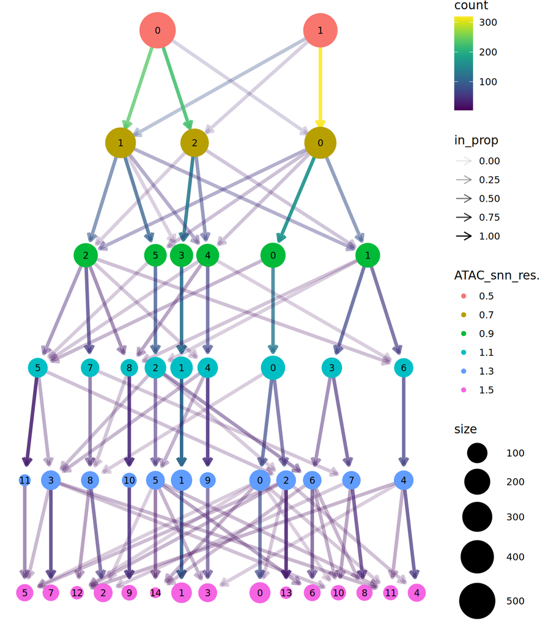

```r
clustree(seu.s)
```

Lastly, we need to rerun `FindClusters` one last time to make sure we use the 0.5 resolution (that we had in the object before but that was overwritten by our code chunk to prepare the `clustree` function) for all subsequent analysis:

```r
# Let's make sure the 0.5 resolution is the one that we keep for further analyses,
# not the last one (1.5) from the chunk above
seu.s = FindClusters(seu.s, resolution = 0.5, algorithm = 1, graph.name = "ATAC_snn", verbose = FALSE)
```

## Save filtered object to disk

We reached the end of the first vignette and the first set of analyses. Finally, we can now save our filtered Seurat object to disk, in analogy to what we did above with the original, unfiltered `Seurat` object.

```r
saveRDS(seu.s, file = paste0(outFolder,"obj.filt.rds"))
```

## Further reading

[10x Genomics: What is Cell Ranger ATAC?](https://support.10xgenomics.com/single-cell-atac/software/pipelines/latest/what-is-cell-ranger-atac)

[scATAC-seq data analysis tools and papers](https://github.com/mdozmorov/scATAC-seq_notes)

[Beginner’s Guide to Understanding Single-Cell ATAC-Seq](https://www.activemotif.com/blog-single-cell-atac-seq)

[scATAC.Explorer: A Collection of Single-cell ATAC Sequencing Datasets and Corresponding Metadata for R/Bioconductor](https://bioconductor.org/packages/release/data/experiment/html/scATAC.Explorer.html)

[ShinyArchR.UiO: user-friendly,integrative and open-source tool for visualization of single-cell ATAC-seq data using ArchR](https://academic.oup.com/bioinformatics/article/38/3/834/6377776)

[Efficient pre-processing of Single-cell ATAC-seq data](https://www.biorxiv.org/content/10.1101/2021.12.08.471788v1)

[Dimensionality Reduction for scATAC Data](http://andrewjohnhill.com/blog/2019/05/06/dimensionality-reduction-for-scatac-data/)

[CellWalkR: R package for integrating and visualizing single-cell and bulk data to resolve regulatory elements](https://academic.oup.com/bioinformatics/article/38/9/2621/6547050)

[scDblFinder R package for doublet detection](https://bioconductor.org/packages/release/bioc/vignettes/scDblFinder)

[Grandi, F.C., Modi, H., Kampman, L. and Corces, M.R., 2022. Chromatin accessibility profiling by ATAC-seq. Nature Protocols, pp.1-35.](https://www.nature.com/articles/s41596-022-00692-9) [2] [Yu, W., Uzun, Y., Zhu, Q., Chen, C. and Tan, K., 2020. scATAC-pro: a comprehensive workbench for single-cell chromatin accessibility sequencing data. Genome biology, 21(1), pp.1-17.](https://genomebiology.biomedcentral.com/track/pdf/10.1186/s13059-020-02008-0.pdf)

[Granja, J.M., Corces, M.R., Pierce, S.E., Bagdatli, S.T., Choudhry, H., Chang, H.Y. and Greenleaf, W.J., 2021. ArchR is a scalable software package for integrative single-cell chromatin accessibility analysis. Nature genetics, 53(3), pp.403-411.](https://www.nature.com/articles/s41588-021-00790-6)

[Hao, Y., Hao, S., Andersen-Nissen, E., Mauck III, W.M., Zheng, S., Butler, A., Lee, M.J., Wilk, A.J., Darby, C., Zager, M. and Hoffman, P., 2021. Integrated analysis of multimodal single-cell data. Cell, 184(13), pp.3573-3587.](https://www.sciencedirect.com/science/article/pii/S0092867421005833)

[Ji, Z., Zhou, W., Hou, W. and Ji, H., 2020. Single-cell ATAC-seq signal extraction and enhancement with SCATE. Genome biology, 21(1), pp.1-36.](https://genomebiology.biomedcentral.com/articles/10.1186/s13059-020-02075-3)

[Baek, S. and Lee, I., 2020. Single-cell ATAC sequencing analysis: From data preprocessing to hypothesis generation. Computational and structural biotechnology journal, 18, pp.1429-1439.](https://www.sciencedirect.com/science/article/pii/S2001037020303019)

A single-cell atlas of chromatin accessibility in the human genome

[Comprehensive analysis of single cell ATAC-seq data with SnapATAC](https://www.nature.com/articles/s41467-021-21583-9)

[Interesting blog post regarding normalization and dimensionality reduction of scATAC data](http://andrewjohnhill.com/blog/2019/05/06/dimensionality-reduction-for-scatac-data/)

## Session info

It is good practice to print the so-called session info at the end of an R script, which prints all loaded libraries, their versions etc. This can be helpful for reproducibility and recapitulating which package versions have been used to produce the results obtained above.

[session information not shown]